# New Mexico Redistricting: Exploring State Senate Maps

2025-11-28

## Introduction

This analysis examines **redistricting** in New Mexico through computational **simulations** of the state’s 42-member senate. Using the [`redist`](https://github.com/alarm-redist/redist) package, we generate 2,000 alternative redistricting plans that comply with New Mexico’s legal requirements: districts must maintain **population balance** within 5%, consist of **contiguous** **precincts**, and respect county boundaries where possible. These requirements are detailed in the [legislative redistricting guidelines](https://www.nmlegis.gov/Redistricting/Documents/134250.pdf).

By applying 2024 election results to these simulated maps, we establish a baseline distribution of possible **partisan** outcomes under legally compliant alternatives. Comparing the existing map to this distribution reveals where it falls within the range of feasible configurations.

The precinct-level data and shapefiles come from the newmexico-political-data repository, and all code is included below for full reproducibility.

## Load Data

This section loads the geographic boundaries and election data needed for redistricting analysis. All data are loaded directly from GitHub. The dataset includes precinct-level results and boundary files for redistricting analysis. Boundary files are available in the [boundaries directory](https://github.com/jaytimm/newmexico-political-data/tree/main/data/boundaries) of the repository.

```r
pacman::p_load(dplyr, ggplot2, tidyr, patchwork, data.table, redist, sf, tidycensus, tigris, purrr, DT)
```

### Load Election Results

```r
# Load precinct-level data from GitHub (2004-2024)
precinct_data <- read.csv("https://raw.githubusercontent.com/jaytimm/newmexico-political-data/main/data/elections/nm_precinct_results_2004-24.csv",
                          stringsAsFactors = FALSE)

# Load final results data from GitHub
results <- read.csv("https://raw.githubusercontent.com/jaytimm/newmexico-political-data/main/data/elections/nm_election_results_2000-24.csv",
                    stringsAsFactors = FALSE)

# Load county-level statewide results from GitHub
county_results <- read.csv("https://raw.githubusercontent.com/jaytimm/newmexico-political-data/main/data/elections/nm_county_statewide_results_2000-24.csv",
                           stringsAsFactors = FALSE)
```

### Load Boundaries

```r
# Load joined precincts with district assignments GeoJSON from GitHub
vtd_with_districts <- st_read("https://raw.githubusercontent.com/jaytimm/newmexico-political-data/main/data/boundaries/nm_vtd_with_districts_2021.geojson") |>
  mutate(ID = as.character(ID))
# Process precinct data for redistricting analysis
# Standardize column names if needed
if("COUNTY_NAM" %in% names(precinct_data)) {
  precinct_data$county_name <- precinct_data$COUNTY_NAM
}
if("VTD_NUM" %in% names(precinct_data)) {
  precinct_data$precinct_name <- as.character(precinct_data$VTD_NUM)
}

# Filter to 2024 for current redistricting analysis
precinct_2024 <- precinct_data |>
  filter(election_date == 2024)

# Prepare election results for redistricting analysis
# Extract 2024 results by office
elections_2024 <- precinct_2024 |>
  filter(office_name %in% c("United States Senator",
                             "President of the United States",
                             "United States Representative"))
```

## Generate Redistricting Plans

We use the `redist` package to generate 2,000 simulated redistricting plans for the state senate. The simulations employ New Mexico’s legal requirements as constraints: population balance within 5%, contiguous precincts, and respect for county boundaries. The **sequential Monte Carlo** (SMC) algorithm explores the space of valid district configurations.

```r
plans_file <- "2025-11-28-new-mexico-redistricting-state-senate/redist_plans.rds"

adj <- redist::redist.adjacency(vtd_with_districts)
map <- redist::redist_map(
  vtd_with_districts,
  adj       = adj,
  ndists    = 42,
  total_pop = POP,
  county    = COUNTY_NAM,
  pop_tol   = 0.05
)

if (file.exists(plans_file)) {
  plans <- readRDS(plans_file)
} else {
  plans <- redist::redist_smc(map, nsims = 2000)
  saveRDS(plans, plans_file)
}
```

### Plot Example Maps

Six example simulated senate mappings from the 2,000 generated plans. Each map represents a different valid redistricting configuration that satisfies New Mexico’s legal requirements.

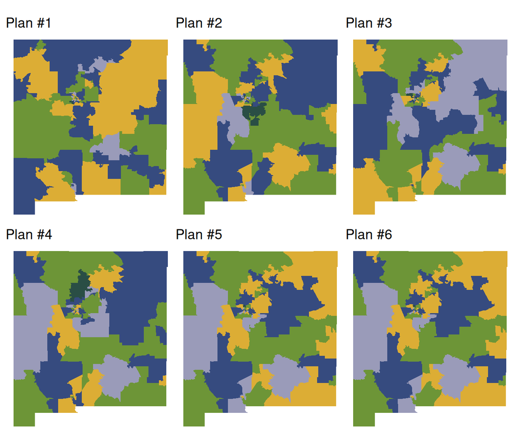

```r
redist.plot.plans(plans, draws=c("1", "2", "3", "4", "5", "6"), shp = map)
```

### Process Plans

The generated plans are stored as a matrix where each column represents a different redistricting plan and each row represents a precinct. We convert this to a data frame format for analysis, merging it with precinct identifiers.

```r
# Convert plans matrix to data.frame
df <- attr(plans, "plans") |> data.frame()
df1 <- vtd_with_districts |>
  st_drop_geometry() |>
  as.data.frame() |>
  select(GEOCODE, COUNTY_NAM, VTD_NUM) |>
  bind_cols(df)

df2 <- df1 |> tidyr::pivot_longer(cols = 4:103)
```

### Compute Partisan Splits

This function aggregates precinct-level election results to the district level for each redistricting plan, then determines which party wins each district based on vote totals.

```r
# Function to compute D/R splits for one election
# Assumes elect_df and df1 have COUNTY_NAM and VTD_NUM as character columns
get_split <- function(elect_df, df1) {
    elect_df <- as.data.table(elect_df)

    # Merge precinct results with district assignments
    m <- merge(elect_df, df1, by = c("COUNTY_NAM", "VTD_NUM"), all.x = TRUE)

    plan_cols <- setdiff(colnames(df1), c("COUNTY_NAM", "VTD_NUM", "GEOCODE"))

    # For each plan, aggregate votes to districts and count D/R seats
    res <- lapply(plan_cols, function(p) {
        tmp <- m[!is.na(get(p))]
        if(nrow(tmp) == 0) return(data.table(seats_D = 0L, seats_R = 0L, plan = p))

        agg <- tmp[, .(dem = sum(dem, na.rm = TRUE), rep = sum(rep, na.rm = TRUE)), by = get(p)]
        setnames(agg, "get", "district")

        agg[, winner := fifelse(dem > rep, "D", "R")]
        agg[, .(seats_D = sum(winner == "D"), seats_R = sum(winner == "R"), plan = p)]
    })

    rbindlist(res)
}
```

## Analyze Election Results

We evaluate each redistricting plan using three different election baselines: 2024 U.S. Senate, 2024 Presidential, and aggregated 2024 Congressional District results. For each plan, we calculate how many districts would be won by Democrats versus Republicans under each election baseline.

```r
# Ensure merge columns are character type
df1$COUNTY_NAM <- as.character(df1$COUNTY_NAM)
df1$VTD_NUM <- as.character(df1$VTD_NUM)

# Define elections to evaluate
election_config <- list(
  list(name = "Senate2024", data = elections_2024 |> filter(office_name == "United States Senator")),
  list(name = "President2024", data = elections_2024 |> filter(office_name == "President of the United States")),
  list(name = "AggCD2024", data = elections_2024 |>
       filter(office_name == "United States Representative" &
              (district_name == "1" | district_name == 1 |
               district_name == "2" | district_name == 2 |
               district_name == "3" | district_name == 3)))
)

# Ensure election data has character merge columns
for(i in seq_along(election_config)) {
  d <- election_config[[i]]$data
  if(!"COUNTY_NAM" %in% names(d) && "county_name" %in% names(d)) {
    d$COUNTY_NAM <- as.character(d$county_name)
  }
  if(!"VTD_NUM" %in% names(d) && "precinct_name" %in% names(d)) {
    d$VTD_NUM <- as.character(d$precinct_name)
  }
  if("COUNTY_NAM" %in% names(d)) d$COUNTY_NAM <- as.character(d$COUNTY_NAM)
  if("VTD_NUM" %in% names(d)) d$VTD_NUM <- as.character(d$VTD_NUM)
  election_config[[i]]$data <- d
}

# Evaluate all elections
final_results <- map_dfr(election_config, function(config) {
  result <- get_split(config$data, df1)
  result[, election := config$name]
  result
})
```

## Interpret the Results

Distribution of Democratic **seat share** across 2,000 simulated redistricting plans using 2024 election results. The orange vertical line represents the existing map (26 Democratic seats). **The existing map aligns with the simulated distribution for the presidential race, but for down-ballot races (Aggregate CD and Senate), it falls toward the lower end – most alternative plans would have yielded 27-30 Democratic seats.**

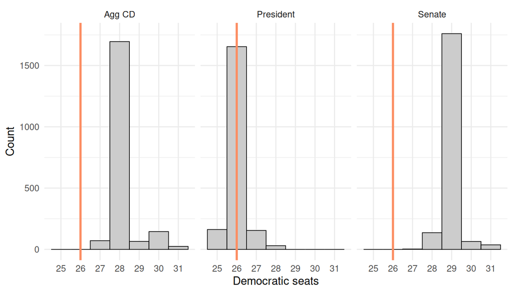

```r
plot_dt <- final_results[
    election %in% c("Senate2024","President2024","AggCD2024"),
    .(seats_D, election)
]

plot_dt[election == "Senate2024",    election := "Senate"]
plot_dt[election == "President2024", election := "President"]
plot_dt[election == "AggCD2024",     election := "Agg CD"]

enacted <- 26L

# Calculate overall x-axis range across all facets
xmin <- floor(min(plot_dt$seats_D))
xmax <- ceiling(max(plot_dt$seats_D))
xbreaks <- seq(xmin, xmax, by = 1)

ggplot(plot_dt, aes(x = seats_D)) +
    geom_histogram(
        binwidth = 1,
        color = "black",
        fill = "grey80",
        linewidth = 0.3,
        boundary = 0.5
    ) +
    geom_vline(
        xintercept = enacted,
        color = "#fc8d62",
        linewidth = 1
    ) +
    facet_wrap(~ election, nrow = 1) +
    scale_x_continuous(
        breaks = xbreaks,
        limits = c(xmin - 0.5, xmax + 0.5),
        minor_breaks = NULL
    ) +
    labs(
        x = "Democratic seats",
        y = "Count"
    ) +
    theme_minimal()
```

## Analyze Split-Ticket Precincts and District Effects

### Identify Precinct-Level Ticket Splits

Winning party for each of the four elections at every precinct – all combinations of winners.

```r
# Get senate district assignments
vtd_senate <- vtd_with_districts |>
  st_drop_geometry() |>
  select(COUNTY_NAM, VTD_NUM, state_senate_district) |>
  mutate(COUNTY_NAM = as.character(COUNTY_NAM),
         VTD_NUM = as.character(VTD_NUM),
         state_senate_district = as.character(state_senate_district))

# Get precinct winners for each election
precinct_winners <- precinct_2024 |>
  filter(office_name %in% c("State Senate", "President of the United States",
                            "United States Senator", "United States Representative")) |>
  group_by(COUNTY_NAM, VTD_NUM, office_name) |>
  summarise(dem = sum(dem, na.rm = TRUE), rep = sum(rep, na.rm = TRUE), .groups = "drop") |>
  #filter(dem > 0 | rep > 0) |>
  mutate(winner = ifelse(dem > rep, "D", "R")) |>
  mutate(office_key = case_when(
    office_name == "State Senate" ~ "winner_state_sen",
    office_name == "President of the United States" ~ "winner_pres",
    office_name == "United States Senator" ~ "winner_us_sen",
    office_name == "United States Representative" ~ "winner_house"
  )) |>
  select(COUNTY_NAM, VTD_NUM, office_key, winner) |>
  pivot_wider(names_from = office_key, values_from = winner)

# Merge with senate districts - ensure all columns exist
precinct_comparison <- vtd_senate |>
  left_join(precinct_winners, by = c("COUNTY_NAM", "VTD_NUM"))

# Count precinct ticket splits showing all race combinations
# Filter out rows with ANY NA before counting (ignore NAs in sums/counts)
precinct_splits_full <- precinct_comparison |>
  filter(!is.na(winner_state_sen) & !is.na(winner_pres) & !is.na(winner_us_sen) & !is.na(winner_house)) |>
  count(winner_state_sen, winner_pres, winner_us_sen, winner_house, name = "Count") |>
  mutate(
    StateSen = as.character(winner_state_sen),
    Pres = as.character(winner_pres),
    USSen = as.character(winner_us_sen),
    House = as.character(winner_house),
    Pct = round(Count / sum(Count) * 100, 1)
  ) |>
  select(StateSen, Pres, USSen, House, Count, Pct) |>
  arrange(desc(Count))

# Format table with red/blue coloring
DT::datatable(
  precinct_splits_full,
  caption = "Winning party combination by precinct - 2024 general election",
  options = list(
    dom = 't',
    paging = FALSE,
    searching = FALSE,
    ordering = TRUE,
    info = FALSE,
    scrollX = TRUE
  ),
  rownames = FALSE
) |>
  DT::formatStyle(
    columns = c("StateSen", "Pres", "USSen", "House"),
    backgroundColor = DT::styleEqual(
      levels = c("D", "R"),
      values = c("rgba(0, 102, 204, 0.3)", "rgba(204, 0, 0, 0.3)")
    )
  )
```

| StateSen | Pres | USSen | House | Count | Pct |
| --- | --- | --- | --- | --- | --- |
| D | D | D | D | 1198 | 55.4 |
| R | R | R | R | 615 | 28.4 |
| R | D | D | D | 103 | 4.8 |
| D | R | R | R | 80 | 3.7 |
| D | R | D | D | 37 | 1.7 |
| R | R | D | R | 30 | 1.4 |
| R | R | D | D | 26 | 1.2 |
| R | D | D | R | 15 | 0.7 |
| D | R | R | D | 13 | 0.6 |
| R | R | R | D | 12 | 0.6 |

[output cut: 6 more lines]

### Aggregate Splits to Senate Districts

Precinct-level results aggregated to the state senate district level, showing how ticket-splitting aggregates into district outcomes and where state senate winners differ from federal election winners.

```r
# Get vote totals by district for each election - aggregate using GeoJSON districts
district_votes <- precinct_2024 |>
  filter(office_name %in% c("State Senate", "President of the United States",
                            "United States Senator", "United States Representative")) |>
  left_join(vtd_senate, by = c("COUNTY_NAM", "VTD_NUM")) |>
  filter(!is.na(state_senate_district)) |>
  group_by(state_senate_district, office_name) |>
  summarise(dem = sum(dem, na.rm = TRUE), rep = sum(rep, na.rm = TRUE), .groups = "drop") |>
  filter(dem > 0 | rep > 0) |>
  mutate(winner = ifelse(dem > rep, "D", ifelse(rep > dem, "R", NA))) |>
  mutate(office_key = case_when(
    office_name == "State Senate" ~ "winner_state_sen_dist",
    office_name == "President of the United States" ~ "winner_pres_dist",
    office_name == "United States Senator" ~ "winner_us_sen_dist",
    office_name == "United States Representative" ~ "winner_house_dist"
  )) |>
  select(state_senate_district, office_key, winner) |>
  pivot_wider(names_from = office_key, values_from = winner)

senate_district_results <- district_votes

# Count senate district splits showing all race combinations
# Filter out rows with ANY NA before counting (ignore NAs in sums/counts)
district_splits_full <- senate_district_results |>
  filter(!is.na(winner_state_sen_dist) & !is.na(winner_pres_dist) & !is.na(winner_us_sen_dist) & !is.na(winner_house_dist)) |>
  count(winner_state_sen_dist, winner_pres_dist, winner_us_sen_dist, winner_house_dist, name = "Count") |>
  mutate(
    StateSen = as.character(winner_state_sen_dist),
    Pres = as.character(winner_pres_dist),
    USSen = as.character(winner_us_sen_dist),
    House = as.character(winner_house_dist)
  ) |>
  select(StateSen, Pres, USSen, House, Count) |>
  arrange(desc(Count))

# Format table with red/blue coloring
DT::datatable(
  district_splits_full,
  options = list(
    dom = 't',
    paging = FALSE,
    searching = FALSE,
    ordering = TRUE,
    info = FALSE,
    scrollX = TRUE
  ),
  rownames = FALSE
) |>
  DT::formatStyle(
    columns = c("StateSen", "Pres", "USSen", "House"),
    backgroundColor = DT::styleEqual(
      levels = c("D", "R"),
      values = c("rgba(0, 102, 204, 0.3)", "rgba(204, 0, 0, 0.3)")
    )
  )
```

| StateSen | Pres | USSen | House | Count |
| --- | --- | --- | --- | --- |
| D | D | D | D | 26 |
| R | R | R | R | 13 |
| R | D | D | D | 1 |
| R | R | D | D | 1 |
| R | R | D | R | 1 |

### Identify Split-Ticket Districts

```r
# Get counties for each district from GeoJSON data
district_counties <- vtd_with_districts |>
  st_drop_geometry() |>
  group_by(state_senate_district) |>
  summarise(Counties = paste(sort(unique(COUNTY_NAM)), collapse = ", "), .groups = "drop") |>
  mutate(state_senate_district = as.character(state_senate_district))

# Identify districts where state senate winner differs from federal winners
flip_districts <- senate_district_results |>
  filter(!is.na(winner_state_sen_dist) & !is.na(winner_pres_dist) & !is.na(winner_us_sen_dist) & !is.na(winner_house_dist)) |>
  mutate(
    # Check if state senate differs from federal races
    differs_from_pres = winner_state_sen_dist != winner_pres_dist,
    differs_from_us_sen = winner_state_sen_dist != winner_us_sen_dist,
    differs_from_house = winner_state_sen_dist != winner_house_dist,
    is_flip = differs_from_pres | differs_from_us_sen | differs_from_house
  ) |>
  filter(is_flip) |>
  mutate(state_senate_district = as.character(state_senate_district)) |>
  left_join(district_counties, by = "state_senate_district") |>
  mutate(
    StateSen = as.character(winner_state_sen_dist),
    Pres = as.character(winner_pres_dist),
    USSen = as.character(winner_us_sen_dist),
    House = as.character(winner_house_dist)
  ) |>
  select(District = state_senate_district, Counties, StateSen, Pres, USSen, House) |>
  arrange(District)

# Format table with red/blue coloring
DT::datatable(
  flip_districts,
  options = list(
    dom = 't',
    paging = FALSE,
    searching = FALSE,
    ordering = TRUE,
    info = FALSE,
    scrollX = TRUE
  ),
  rownames = FALSE
) |>
  DT::formatStyle(
    columns = c("StateSen", "Pres", "USSen", "House"),
    backgroundColor = DT::styleEqual(
      levels = c("D", "R"),
      values = c("rgba(0, 102, 204, 0.3)", "rgba(204, 0, 0, 0.3)")
    )
  )
```

| District | Counties | StateSen | Pres | USSen | House |
| --- | --- | --- | --- | --- | --- |
| 12 | Bernalillo, Sandoval | R | R | D | R |
| 21 | Bernalillo | R | D | D | D |
| 28 | Grant, Hidalgo, Luna | R | R | D | D |